# Course-Book, Costello Medical

Making Health Economic Evaluation Shiny: A tutorial

Robert Smith, Paul Schneider & Sarah Bates (Dark Peak Analytics)

14, February, 2021

# Introduction

You can find all materials from this short course on our [Github Repository](https://github.com/bitowaqr/emsr_course). Feel free to use any code from this repository, but make sure you cite the following peer reviewed article:

Smith R and Schneider P. Making health economic models Shiny: A tutorial. Wellcome Open Res 2020, 5:69 https://doi.org/10.12688/wellcomeopenres.15807.2

This short course is designed to provide the participant with a basic understanding of health economic modelling in R and using R Shiny, to create user-interfaces. The aim is to ensure delegates understand the basic functionality of a Health Economic Evaluation Model constructed in R and displayed in a user-interface created in R-Shiny.

The course makes use of the authors experiences of working with R for data-science and statistical analysis. However there are many other resources available, and we would particularly recommend the freely available content at *[R for Data Science](https://r4ds.had.co.nz/)* as a good place to recap the materials taught in this course. The hard copy of Hadley Wickham and Garrett Grolemund’s book of the same name (and content) is available at *[Amazon.com](https://r4ds.had.co.nz/)*. Alternatively, a user guide is available on the CRAN R-Project website [here](https://cran.r-project.org/doc/manuals/r-release/R-intro.html), although the authors find this less easy to follow than Hadley Wickham’s book described above. Further details of where to go to answer more specific questions are provided throughout the course.

## Who are we

Rob, Paul & Sarah work at the intersection between public health, economics and data-science. They are based at the School of Health and Related Research at the University of Sheffield.

*[Robert Smith](https://www.linkedin.com/in/robert-smith-53b28438/)* is affiliated with ScHARR, University of Sheffield, the Joint Biosecurity Centre, Department of Health and Social Care, and Dark Peak Analytics, a company he founded in 2020 with Paul Schneider. His research focuses on the methods used to estimate the costs and benefits of public health interventions, with a specific interest in microsimulation modelling in R. He has become increasingly interested in the use of web based user interfaces (in R-Shiny) to make research more transparent and to aid decision makers. Robert has been involved in multiple projects with the World Health Organization, and is currently working in Advanced Analytics at the Joint Biosecurity Centre.

*[Paul Schneider](https://bitowaqr.github.io/)* is based at ScHARR, University of Sheffield and a co-founder of Dark Peak Analytics. His research is focused on conceptual and methodological problems in valuing health outcomes in economic evaluations. A medical doctor and epidemiologist by training, he has used R in various research projects, ranging from the modeling costs of breast cancer, and value of information analyses, to the monitoring of influenza in real-time using online data. He is a keen advocate of open science practices.

*[Sarah Bates](https://www.linkedin.com/in/sarah-elizabeth-bates-647ab9145/)* joined Dark Peak Analytics in 2020. She has previously taught a number of postgraduate courses in Health Economics & Decision Science at ScHARR (University of Sheffield), where her PhD was focused on the feasibility of including psychological factors in health economic models of behavioural weight management interventions.

## Course prerequisites

We recommend that those attending the course have undertaken training in R and health economic evaluation (including state transition models) prior to the course. For an introduction to R see our previous course here [Intro2R](https://github.com/ScHARR-PHEDS/R4ScHARR). In particular those we assume prior knowledge of custom functions, lists, sourcing R files, loading packages, loops & matrix multiplication (%*%). It would also be useful to play with some basic shiny applications prior to the course, a 20 minute tutorial can be found here: https://shiny.rstudio.com/tutorial/. It is essential that participants have installed R and RStudio and have installed the Shiny package prior to the course.

## Installing R and R Studio.

R is a free software environment for statistical analysis and data science. It is a collaborative effort started by Robert Gentleman and Ross Ihaka in New Zealand, but now made up of hundreds of people. R is made freely available by the Comprehensive R archive Network (CRAN), in the UK it can be downloaded through the University of Bristol *[here](https://www.stats.bris.ac.uk/R/)*.There are options of downloading R for Linux, Mac and Windows.

Downloading R gives you the basic software environment, but an incredibly popular add-on called ‘RStudio’ is required to follow this course. You should download the free ‘RStudio Desktop Open Source Licence’ version for the laptop you will be attending the course with from *[RStudio.com](https://www.rstudio.com/products/rstudio/#Desktop)*. If you have time before the course, it would be hugely beneficial to get familiar with RStudio.

# Partitioned Survival Models (PSM)

### Recap

- In a Partitioned Survival Model (PSM), individuals reside in one of a series of mutually exclusive and jointly exhaustive health states.
- State membership is usually determined by a series of independently modelled non-mutually exclusive survival curves.
- A survival curve must be specified for each alive health state that describes time from model start until transiting to another health state.
- Evaluating PSM is different to Markov models. Health state occupancy ( *sojourn*) time is estimated directly from curves (as integral/AUC), rather than as function of transition matrices.

### TUTORIAL

Suppose you have been asked to evaluate a new treatment ‘Supimab’, against the standard-of-care treatment (SOC). The model has the following specifications:

Treatment options

- **SUPIMAP**
- **STANDARD-OF-CARE (SOC)**

Model type: PSM with three states

- PFS = Progression-free survival
- PPS = Post-progression survival (= OS - PFS)
- dead (= 1 - OS) (N.B.: OS = overall survival = PFS + PPS)

Patients in PFS receive either supimab or SOC. After disease progression, all patients stop their treatment and receive supportive care.

### Setup

```r
  options(scipen=99, digits=3)

## load packages
  library(knitr)
  library(survival)
  library(flexsurv)
  library(ggplot2)
```

### Preamble

**Fitting parametric survival models and retrieving parameters for the PSM**

Suppose we have some individual patient data from a clinical trial, in which 200 participants were randomised to either receiving standard of care or the new drug Supimab (100 to each group). In the trial, the time until progression and the time until death were recorded. For simplicity, there will be no censoring of data. (The individual patient data was simulated using the simsurv package - see [source code](https://github.com/bitowaqr/emsr_course/blob/main/PSM/sim_surv.R))

We will (1) load the data sets, (2) fit a Weibull model (PH) to both OS and PFS data, and then (3) retrieve the shape and scale parameters, which we will use in the PSM model.

```r
## Overall survival data
# 1 load data and fit parametric models
  df_os <- read.csv("../PSM/data/trial_os.csv")
  head(df_os)
```

```
##   id trt eventtime status
## 1  1 SOC     1.314      1
## 2  2 SOC     1.164      1
## 3  3 SOC     0.547      1
## 4  4 SOC     2.277      1
## 5  5 SOC     0.777      1
## 6  6 SOC     1.153      1
```

```r
# 2 fit a paraetric survival model
  surv_os <- Surv(time = df_os$eventtime, event = df_os$status)
  os_reg <- flexsurvreg(surv_os ~ trt, data = df_os,dist = "weibullph")
  os_reg
```

```
## Call:
## flexsurvreg(formula = surv_os ~ trt, data = df_os, dist = "weibullph")
##
## Estimates:
##             data mean  est      L95%     U95%     se       exp(est)  L95%
## shape            NA     1.5308   1.3751   1.7041   0.0838       NA        NA
## scale            NA     0.5459   0.4354   0.6844   0.0630       NA        NA
## trtSupimab   0.5000    -0.6914  -0.9768  -0.4060   0.1456   0.5009    0.3765
##             U95%
## shape            NA
## scale            NA
## trtSupimab   0.6663
##
## N = 200,  Events: 200,  Censored: 0
## Total time at risk: 345
## Log-likelihood = -280, df = 3
## AIC = 565
```

```r
# 3 retrieve parameters from models
  os_shape <- os_reg$res[1,1]
  os_shape
```

```
## [1] 1.53
```

```r
  os_scale_soc <- os_reg$res[2,1]
  os_scale_soc
```

```
## [1] 0.546
```

```r
  os_scale_supi <- os_reg$res[2,1] * exp(os_reg$res[3,1])
  os_scale_supi
```

```
## [1] 0.273
```

```r
## repeat the same for PFS
## Progression-free survival
# 1 load data and fit parametric models
  df_pfs <- read.csv("../PSM/data/trial_pfs.csv")
  head(df_pfs)
```

```
##   id trt eventtime status
## 1  1 SOC     1.024      1
## 2  2 SOC     0.457      1
## 3  3 SOC     0.669      1
## 4  4 SOC     0.702      1
## 5  5 SOC     0.108      1
## 6  6 SOC     0.547      1
```

```r
# 2 fit a paraetric survival model
  surv_pfs <- Surv(time = df_pfs$eventtime, event = df_pfs$status)
  pfs_reg <- flexsurvreg(surv_pfs ~ trt, data = df_pfs,dist = "weibullph")
  pfs_reg
```

```
## Call:
## flexsurvreg(formula = surv_pfs ~ trt, data = df_pfs, dist = "weibullph")
##
## Estimates:
##             data mean  est      L95%     U95%     se       exp(est)  L95%
## shape            NA     1.5434   1.3825   1.7229   0.0867       NA        NA
## scale            NA     2.3894   1.9515   2.9255   0.2468       NA        NA
## trtSupimab   0.5000    -0.9992  -1.2972  -0.7011   0.1521   0.3682    0.2733
##             U95%
## shape            NA
## scale            NA
## trtSupimab   0.4960
##
## N = 200,  Events: 200,  Censored: 0
## Total time at risk: 149
## Log-likelihood = -107, df = 3
## AIC = 219
```

```r
# 3 retrieve parameters from models
  pfs_shape <- pfs_reg$res[1,1]
  pfs_shape
```

```
## [1] 1.54
```

```r
  pfs_scale_soc <- pfs_reg$res[2,1]
  pfs_scale_soc
```

```
## [1] 2.39
```

```r
  pfs_scale_supi <- pfs_reg$res[2,1] * exp(pfs_reg$res[3,1])
  pfs_scale_supi
```

```
## [1] 0.88
```

### Define model parameters

Parameters

| **Supimab** |  |
| --- | --- |
| costs drug | 30000 |
| costs administration | 2000 |
| OS (Weibull): |  |
| shape | 1.530795 |
| scale | 0.2734298 |
| PFS (Weibull): |  |
| shape | 1.543373 |
| scale | 0.8797236 |
| **SOC** |  |
| drug costs | 22000 |
| OS (Weibull) |  |
| shape | 1.530795 |
| scale | 0.5459197 |
| PFS (Weibull) |  |
| shape | 1.543373 |
| scale | 2.389363 |
| **Other** |  |
| utility PFS | 0.9 |
| utility PPS | 0.65 |
| costs PPS | 5000 |
| Time horizon | 10 years |
| Discount rate | 3.5% |

To illustrate how the PSM works, we will use very large time intervals of one year - in practice, the interval should be much smaller, i.e. 1 day.

```r
  # Define horizon and time intervals
  times <- seq(from = 0, to = 10, by = 1) # NOTE: 1 interval = 1 year

  # utilities
  u_pfs <- 0.90
  u_pps <-  0.65

  # costs soc
  c_soc <- 22000

  # costs supimab
  c_drug_supi <- 30000
  c_admin_supi <- 2000
  c_supi <- c_drug_supi + c_admin_supi

  # costs supportive care for post-progression
  c_support <- 5000

  # discount rate
  disc_rate = 0.035
```

### Predict cumulative survival curves for OS, PFS, PPS & Dead

```r
  ## OS curves
  pred_os_soc <- 1 - os_reg$dfns$p(times,shape=os_shape,scale = os_scale_soc)
  pred_os_supi <- (1 - os_reg$dfns$p(times,shape=os_shape, scale = os_scale_supi))

  ## PFS curves
  pred_pfs_soc <- 1 - pfs_reg$dfns$p(times,shape=pfs_shape,scale = pfs_scale_soc)
  pred_pfs_supi <- (1 - pfs_reg$dfns$p(times,shape=pfs_shape, scale = pfs_scale_supi))

  ## PPS curves
  pred_pps_soc <- pred_os_soc - pred_pfs_soc
  pred_pps_supi <- pred_os_supi - pred_pfs_supi

  ## dead curves
  pred_dead_soc <- 1 - pred_os_soc
  pred_dead_supi <- 1 - pred_os_supi

  # Combine estimated survival curves into a matrix
  mat_surv <- cbind(
    pred_pfs_soc, pred_pps_soc, pred_dead_soc,
    pred_pfs_supi, pred_pps_supi, pred_dead_supi
  )
  kable(mat_surv,digits = 3)
```

| pred_pfs_soc | pred_pps_soc | pred_dead_soc | pred_pfs_supi | pred_pps_supi | pred_dead_supi |
| --- | --- | --- | --- | --- | --- |
| 1.000 | 0.000 | 0.000 | 1.000 | 0.000 | 0.000 |
| 0.092 | 0.488 | 0.421 | 0.415 | 0.346 | 0.239 |
| 0.001 | 0.206 | 0.793 | 0.077 | 0.377 | 0.546 |
| 0.000 | 0.053 | 0.947 | 0.008 | 0.222 | 0.770 |
| 0.000 | 0.010 | 0.990 | 0.001 | 0.101 | 0.898 |
| 0.000 | 0.002 | 0.998 | 0.000 | 0.040 | 0.960 |
| 0.000 | 0.000 | 1.000 | 0.000 | 0.014 | 0.986 |
| 0.000 | 0.000 | 1.000 | 0.000 | 0.005 | 0.995 |
| 0.000 | 0.000 | 1.000 | 0.000 | 0.001 | 0.999 |
| 0.000 | 0.000 | 1.000 | 0.000 | 0.000 | 1.000 |
| 0.000 | 0.000 | 1.000 | 0.000 | 0.000 | 1.000 |

### Visualise fitted survival curves

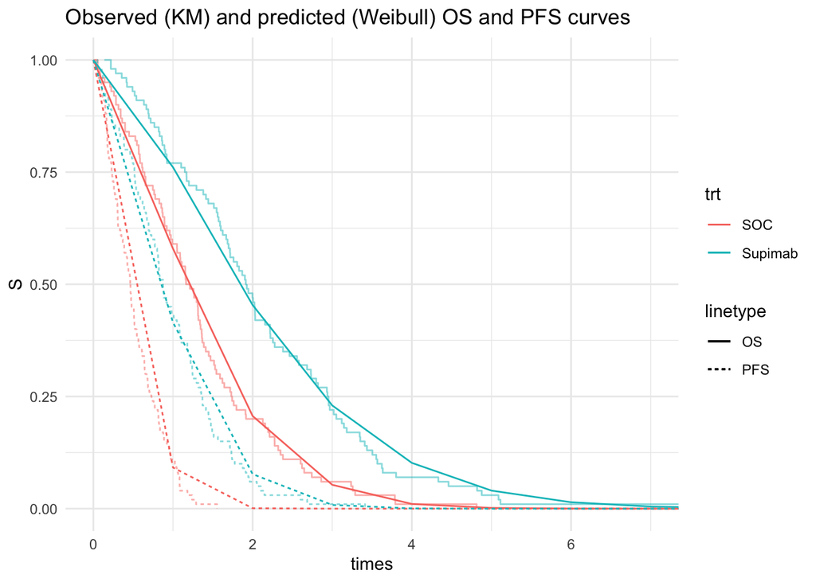

```r
  ### visual inpsection of curves ------
  kmPlotter <- function(event_times, group){
    # simplified KM plot df function
    # can only be used when there is NO CENSORING!
    uniq_g <- unique(group)
    res<- c()
    for(g in uniq_g){
      times <- event_times[group ==g]
      min_t <- min(times)
      max_t <- max(times)
      uniq_t <- unique(times)
      uniq_t <- uniq_t[order(uniq_t)]
      n <- length(times)
      S <- c(1)
      for(t in 2:length(uniq_t)){
        post_n <- sum(times > uniq_t[t])
        S <- c(S,post_n/ n  )
      }
      df <- data.frame(times = uniq_t, S, trt = g)
      res <- rbind(res,df)
    }

    return(res)
  }

  km_plot_os <- kmPlotter(df_os$eventtime,df_os$trt)
  km_plot_pfs <- kmPlotter(df_pfs$eventtime,df_pfs$trt)


  # PLOT OBSERVED AND PREDICTED TOGETHER
  ggplot() +
    # OS KM observed
    geom_step(data = km_plot_os,aes(x=times, y= S, col = trt, linetype="OS"), alpha = 0.5) +
    # PFS KM observed
    geom_step(data = km_plot_pfs,aes(x=times, y= S, col = trt, linetype="PFS"), alpha = 0.5) +

    # Weibull est OS
    geom_line(aes(x=times,y=pred_os_soc,col = "SOC", linetype="OS" )) +
    geom_line(aes(x=times,y=pred_os_supi, col="Supimab",linetype="OS" )) +
    # Weibull est PFS
    geom_line(aes(x=times,y=pred_pfs_soc,col = "SOC", linetype="PFS" )) +
    geom_line(aes(x=times,y=pred_pfs_supi, col="Supimab",linetype="PFS" )) +
    ggtitle("Observed (KM) and predicted (Weibull) OS and PFS curves") +
    coord_cartesian(xlim=c(0,7)) +
    theme_minimal()
```

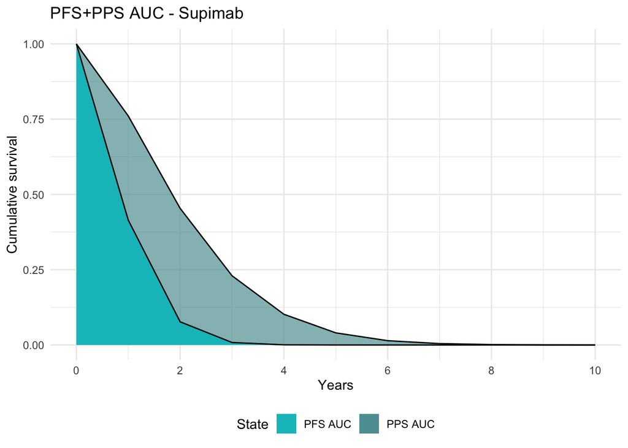

```r
  # AUC
  ## visualise AUC PPS + PFS Supimab
  ggplot() +
    geom_ribbon(aes(x = times, ymin = 0,ymax = pred_pfs_supi, fill = "PFS")) +
    geom_ribbon(aes(x = times, ymin = pred_pfs_supi,ymax = pred_os_supi, fill = "PPS"), alpha = 0.7) +
    geom_line(aes(x = times, y = pred_pfs_supi)) +
    geom_line(aes(x = times, y = pred_os_supi)) +
    ## labels, axes, and legend
    ggtitle("PFS+PPS AUC - Supimab ") +
    ylab("Cumulative survival") +
    scale_x_continuous(name = "Years", breaks = seq(0,10,2)) +
    scale_fill_manual(name = "State",
                      labels = c("PFS AUC","PPS AUC"),
                      values = c("#00BFC4","cadetblue")) +
    theme_minimal() +
    theme(legend.position = "bottom")
```

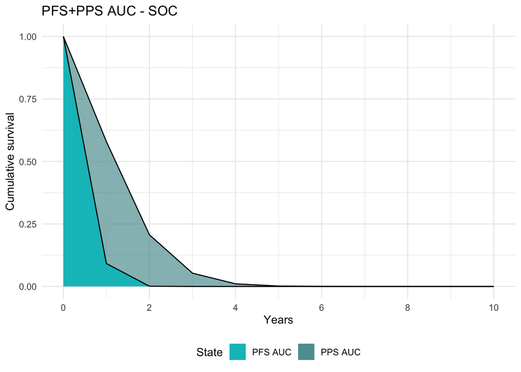

```r
  ## visualise AUC PPS + PFS SOC
  ggplot() +
    geom_ribbon(aes(x = times, ymin = 0,ymax = pred_pfs_soc, fill = "PFS")) +
    geom_ribbon(aes(x = times, ymin = pred_pfs_soc,ymax = pred_os_soc, fill = "PPS"), alpha = 0.7) +
    geom_line(aes(x = times, y = pred_pfs_soc)) +
    geom_line(aes(x = times, y = pred_os_soc)) +
    ## labels, axes, and legend
    ggtitle("PFS+PPS AUC - SOC ") +
    ylab("Cumulative survival") +
    scale_x_continuous(name = "Years", breaks = seq(0,10,2)) +
    scale_fill_manual(name = "State",
                      labels = c("PFS AUC","PPS AUC"),
                      values = c("#00BFC4","cadetblue")) +
    theme_minimal() +
    theme(legend.position = "bottom")
```

### Compute AUCs

> trapezium rule AUC = ( (y2+y1)/2)*(x2 - x1)

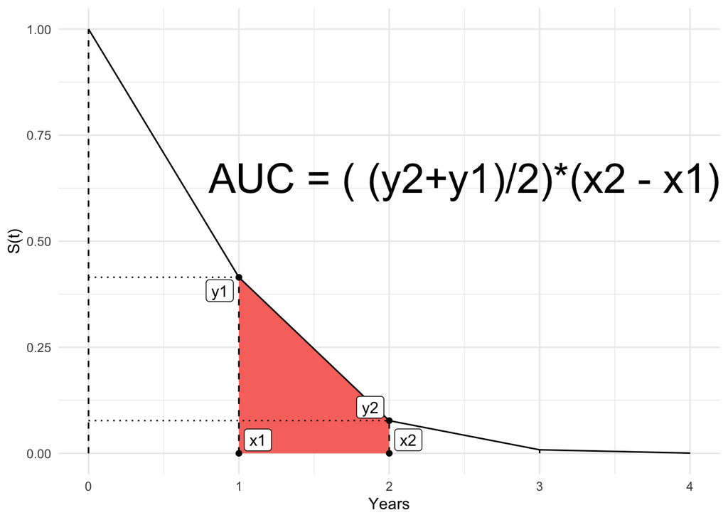

```r
# define and apply AUC function
  myAUC <- function(x, y){
    auc <- rep(NA, times = length(x)-1)
    for (i in 2:(length(x))) {
      auc_i <- ( (y[i] + y[i - 1])/2 ) * (x[i] - x[i - 1])
      auc[i-1] <- auc_i
    }
    return(auc)
  }

  mat_auc <- apply(mat_surv,2,myAUC,x = times)
  kable(mat_auc,digits = 3)
```

| pred_pfs_soc | pred_pps_soc | pred_dead_soc | pred_pfs_supi | pred_pps_supi | pred_dead_supi |
| --- | --- | --- | --- | --- | --- |
| 0.546 | 0.244 | 0.210 | 0.707 | 0.173 | 0.120 |
| 0.046 | 0.347 | 0.607 | 0.246 | 0.361 | 0.393 |
| 0.000 | 0.129 | 0.870 | 0.043 | 0.299 | 0.658 |
| 0.000 | 0.032 | 0.968 | 0.004 | 0.162 | 0.834 |
| 0.000 | 0.006 | 0.994 | 0.000 | 0.071 | 0.929 |
| 0.000 | 0.001 | 0.999 | 0.000 | 0.027 | 0.973 |
| 0.000 | 0.000 | 1.000 | 0.000 | 0.009 | 0.991 |
| 0.000 | 0.000 | 1.000 | 0.000 | 0.003 | 0.997 |
| 0.000 | 0.000 | 1.000 | 0.000 | 0.001 | 0.999 |
| 0.000 | 0.000 | 1.000 | 0.000 | 0.000 | 1.000 |

```r
  ## Run some basic checks
  rowSums(mat_auc) # time stepes check
```

```
##  [1] 2 2 2 2 2 2 2 2 2 2
```

```r
  sum(mat_auc) # total auc check
```

```
## [1] 20
```

```r
  colSums(mat_auc) # time spend in state
```

```
##   pred_pfs_soc   pred_pps_soc  pred_dead_soc  pred_pfs_supi  pred_pps_supi
##          0.593          0.759          8.649          1.001          1.107
## pred_dead_supi
##          7.892
```

### Multiply costs and utilities with computed AUCs

```r
  c_pfs_supi <- mat_auc[,"pred_pfs_supi"] * c_supi
  c_pps_supi <- mat_auc[,"pred_pps_supi"] * c_support
  c_pfs_soc <- mat_auc[,"pred_pfs_soc"] * c_soc
  c_pps_soc <- mat_auc[,"pred_pps_soc"] * c_support

  q_pfs_supi <- mat_auc[,"pred_pfs_supi"] * u_pfs
  q_pps_supi <- mat_auc[,"pred_pps_supi"] * u_pps
  q_pfs_soc <- mat_auc[,"pred_pfs_soc"] * u_pfs
  q_pps_soc <- mat_auc[,"pred_pps_soc"] * u_pps

  # combines costs and qalys into matrices
  # costs
  c_mat <- cbind(c_pfs_supi, c_pps_supi, c_pfs_soc, c_pps_soc)
  kable(c_mat,digits = 2)
```

| c_pfs_supi | c_pps_supi | c_pfs_soc | c_pps_soc |
| --- | --- | --- | --- |
| 22638.36 | 864.67 | 12008.57 | 1219.05 |
| 7870.08 | 1806.76 | 1018.96 | 1732.96 |
| 1364.16 | 1496.40 | 10.42 | 646.83 |
| 141.52 | 807.87 | 0.02 | 159.13 |
| 9.50 | 354.15 | 0.00 | 30.31 |
| 0.43 | 136.37 | 0.00 | 4.62 |
| 0.01 | 47.34 | 0.00 | 0.57 |
| 0.00 | 14.97 | 0.00 | 0.06 |
| 0.00 | 4.34 | 0.00 | 0.01 |
| 0.00 | 1.16 | 0.00 | 0.00 |

```r
  # qalys
  q_mat <- cbind(q_pfs_supi, q_pps_supi, q_pfs_soc, q_pps_soc)
  kable(q_mat, digits = 3)
```

| q_pfs_supi | q_pps_supi | q_pfs_soc | q_pps_soc |
| --- | --- | --- | --- |
| 0.637 | 0.112 | 0.491 | 0.158 |
| 0.221 | 0.235 | 0.042 | 0.225 |
| 0.038 | 0.195 | 0.000 | 0.084 |
| 0.004 | 0.105 | 0.000 | 0.021 |
| 0.000 | 0.046 | 0.000 | 0.004 |
| 0.000 | 0.018 | 0.000 | 0.001 |
| 0.000 | 0.006 | 0.000 | 0.000 |
| 0.000 | 0.002 | 0.000 | 0.000 |
| 0.000 | 0.001 | 0.000 | 0.000 |
| 0.000 | 0.000 | 0.000 | 0.000 |

### Define discount function and apply it to costs and qalys

Discounting: x /(1 + disc_rate) ^ time e.g. cost /(1.035) ^ 0.05

```r
  myDiscounter <- function(x, time, rate = 0.035){
    res <- x /(1 + rate) ^ time
    return(res)
  }

  # apply discounting to cost matrix
  c_mat_disc <- apply(c_mat, 2, myDiscounter, time = times[-1])
  kable(c_mat_disc,digits = 2)
```

| c_pfs_supi | c_pps_supi | c_pfs_soc | c_pps_soc |
| --- | --- | --- | --- |
| 21872.81 | 835.43 | 11602.48 | 1177.83 |
| 7346.81 | 1686.63 | 951.21 | 1617.74 |
| 1230.39 | 1349.66 | 9.40 | 583.40 |
| 123.32 | 704.02 | 0.02 | 138.67 |
| 8.00 | 298.19 | 0.00 | 25.52 |
| 0.35 | 110.94 | 0.00 | 3.76 |
| 0.01 | 37.21 | 0.00 | 0.45 |
| 0.00 | 11.37 | 0.00 | 0.04 |
| 0.00 | 3.19 | 0.00 | 0.00 |
| 0.00 | 0.82 | 0.00 | 0.00 |

```r
  # apply discounting to qaly matrix
  q_mat_disc <- apply(q_mat,2,myDiscounter,time = times[-1])
  kable(q_mat_disc, digits = 3)
```

| q_pfs_supi | q_pps_supi | q_pfs_soc | q_pps_soc |
| --- | --- | --- | --- |
| 0.615 | 0.109 | 0.475 | 0.153 |
| 0.207 | 0.219 | 0.039 | 0.210 |
| 0.035 | 0.175 | 0.000 | 0.076 |
| 0.003 | 0.092 | 0.000 | 0.018 |
| 0.000 | 0.039 | 0.000 | 0.003 |
| 0.000 | 0.014 | 0.000 | 0.000 |
| 0.000 | 0.005 | 0.000 | 0.000 |
| 0.000 | 0.001 | 0.000 | 0.000 |
| 0.000 | 0.000 | 0.000 | 0.000 |
| 0.000 | 0.000 | 0.000 | 0.000 |

### Sum total (discounted) costs and qalys and compute ICER + INB

```r
## costs supimab
  total_costs_supi <- sum(c_mat_disc[,c("c_pfs_supi","c_pps_supi")])
  total_costs_supi
```

```
## [1] 35619
```

```r
  ## costs soc
  total_costs_soc <- sum(c_mat_disc[,c("c_pfs_soc","c_pps_soc")])
  total_costs_soc
```

```
## [1] 16111
```

```r
  ## qalys supimab
  total_qalys_supi <-sum(q_mat_disc[,c("q_pfs_supi","q_pps_supi")])
  total_qalys_supi
```

```
## [1] 1.51
```

```r
  ## qalys soc
  total_qalys_soc <- sum(q_mat_disc[,c("q_pfs_soc","q_pps_soc")])
  total_qalys_soc
```

```
## [1] 0.975
```

```r
  ## ICER
  mean( (total_costs_supi - total_costs_soc) / (total_qalys_supi - total_qalys_soc) )
```

```
## [1] 36136
```

```r
  ## INB at 20k
  inb_20 <-  (total_qalys_supi - total_qalys_soc) * 20000 - (total_costs_supi - total_costs_soc)
  inb_20
```

```
## [1] -8711
```

```r
  ## INB at x
  wtp_steps <- seq(0,50000,1000)
  inb_x <- (total_qalys_supi - total_qalys_soc) * wtp_steps - (total_costs_supi - total_costs_soc)
  kable(cbind(wtp_steps,inb_x), digits = 0)
```

| wtp_steps | inb_x |
| --- | --- |
| 0 | -19509 |
| 1000 | -18969 |
| 2000 | -18429 |
| 3000 | -17889 |
| 4000 | -17349 |
| 5000 | -16809 |
| 6000 | -16269 |
| 7000 | -15730 |
| 8000 | -15190 |
| 9000 | -14650 |
| 10000 | -14110 |
| 11000 | -13570 |
| 12000 | -13030 |
| 13000 | -12490 |
| 14000 | -11950 |
| 15000 | -11411 |
| 16000 | -10871 |
| 17000 | -10331 |
| 18000 | -9791 |
| 19000 | -9251 |
| 20000 | -8711 |
| 21000 | -8171 |
| 22000 | -7632 |
| 23000 | -7092 |
| 24000 | -6552 |
| 25000 | -6012 |
| 26000 | -5472 |
| 27000 | -4932 |
| 28000 | -4392 |
| 29000 | -3852 |
| 30000 | -3313 |
| 31000 | -2773 |
| 32000 | -2233 |
| 33000 | -1693 |
| 34000 | -1153 |
| 35000 | -613 |
| 36000 | -73 |
| 37000 | 467 |
| 38000 | 1006 |
| 39000 | 1546 |
| 40000 | 2086 |
| 41000 | 2626 |
| 42000 | 3166 |
| 43000 | 3706 |
| 44000 | 4246 |
| 45000 | 4785 |
| 46000 | 5325 |
| 47000 | 5865 |
| 48000 | 6405 |
| 49000 | 6945 |
| 50000 | 7485 |

# Markov Model

## Introduction

### Objectives

- Understand the functions needed to build a simple Markov model
- Understand and apply matrix multiplication to speed up a Markov model
- Implement probabilistic sensitivity analysis (PSA)
- Create a ‘wrapper’ function which will facilitate the development of the R shiny app

## Input parameters

The first step in the model is to define the input parameters in R. Below, we define the strategies, the age of the individuals at baseline, the maximum age of follow-up, the time horizon and the discount rate.

```r
Strategies <- c("No Treatment", "Treatment")  # strategy names
age     <- 25                                 # age at baseline
max_age <- 55                                 # maximum age of follow up
n_t  <- max_age - age                         # time horizon, number of cycles
d_r <- 0.03                                   # equal discount of costs and QALYs by 3%

# Transition probabilities (per cycle)
p_HD    <- 0.005           # probability to die when healthy
p_HS1   <- 0.15              # probability to become sick when healthy
p_S1H   <- 0.5               # probability to become healthy when sick
p_S1S2  <- 0.105             # probability to become sicker when sick
hr_S1   <- 3                 # hazard ratio of death in sick vs healthy
hr_S2   <- 10                # hazard ratio of death in sicker vs healthy

# Cost and utility inputs
c_H     <- 2000            # cost of remaining one cycle in the healthy state
c_S1    <- 4000            # cost of remaining one cycle in the sick state
c_S2    <- 15000           # cost of remaining one cycle in the sicker state
c_Trt   <- 12000           # cost of treatment(per cycle)
c_D     <- 0               # cost of being in the death state
u_H     <- 1               # utility when healthy
u_S1    <- 0.75            # utility when sick
u_S2    <- 0.5             # utility when sicker
u_D     <- 0               # utility when dead
u_Trt   <- 0.95            # utility when being treated
```

We need to generate the transition probabilities of death in the sick and sicker states (*p_S1D* and *p_S2D*). First we calculate the rate of death in healthy individuals:

```r
# rate of death in healthy
    r_HD    <- - log(1 - p_HD)
```

Then, using the hazard ratio of death for individuals in the sick and sicker states compared to the healthy state, we calculate the rate of death in those who are in the sick and sicker states.

```r
# rate of death in sick
    r_S1D   <- hr_S1 * r_HD
    # rate of death in sicker
    r_S2D   <- hr_S2 * r_HD
```

This enables us to calculate the probability of death (i.e. moving to the death state) in the sick and sicker health states.

```r
 # probability of death in sick
    p_S1D   <- 1 - exp(-r_S1D)
 # probability of death in sicker
    p_S2D   <- 1 - exp(-r_S2D)
```

```r
# calculate discount weight for each cycle
    v_dwe <- v_dwc <- 1 / (1 + d_r) ^ (0:n_t)
```

Finally we define the names of the health states (H, S1, S2 and D) and create a variable equal to the number of health states

```r
v_n  <- c("H", "S1", "S2", "D")               # the 4 states of the model: Healthy (H), Sick (S1), Sicker                                                  (S2), Dead (D)
n_states <- length(v_n)                            # number of health states
```

## Transition Matrix

We now have all the probabilities that we need to create a transition matrix.

We use the *matrix* function. In this function, we state that the number of rows and number of columns needs to equal the number of states such that there is a column and a row corresponding to each health state. The *dimnames* part of the function is used to define the row and column names. This takes a list in which the first item is a vector of row names and the second item is a vector of column names). In this case the rows and the columns names are the same and correspond to the names of the health states (*v_n*). The matrix initially contains all zeros, hence *data = 0*. In the code below we have labelled the matrix *m_P*.

```r
#transition probability matrix for NO treatment
    m_P <- matrix(data = 0,
                  nrow = n_states,
                  ncol = n_states,
                  dimnames = list(v_n, v_n))

    m_P
```

```
##    H S1 S2 D
## H  0  0  0 0
## S1 0  0  0 0
## S2 0  0  0 0
## D  0  0  0 0
```

We then need to populate the transition matrix. Square brackets are used to identify the row and column in the matrix. The row and column names can be used as has been done below but numbers can also be used. For example, the transition probability for Healthy to Healthy will be the first value in the first row of the matrix (*m_P*) and can be represented by *m_P[“H”, “H”]* or *m_P[1, 1]*.

For more information on matrices in R see: https://www.datamentor.io/r-programming/matrix/. Or use type ?matrix into the console for an R vignette.

```r
 ### From Healthy
    m_P["H", "H"]  <- 1 - (p_HS1 + p_HD)
    m_P["H", "S1"] <- p_HS1
    m_P["H", "D"]  <- p_HD
    ### From Sick
    m_P["S1", "H"]  <- p_S1H
    m_P["S1", "S1"] <- 1 - (p_S1H + p_S1S2 + p_S1D)
    m_P["S1", "S2"] <- p_S1S2
    m_P["S1", "D"]  <- p_S1D
    ### From Sicker
    m_P["S2", "S2"] <- 1 - p_S2D
    m_P["S2", "D"]  <- p_S2D
    ### From Dead
    m_P["D", "D"] <- 1

    m_P
```

```
##        H   S1    S2      D
## H  0.845 0.15 0.000 0.0050
## S1 0.500 0.38 0.105 0.0149
## S2 0.000 0.00 0.951 0.0489
## D  0.000 0.00 0.000 1.0000
```

## Markov trace

A Markov trace matrix is used to track the proportion of individuals in each health state in each cycle. In this matrix, there is one column for each health state and one row for each cycle (plus another row for the baseline values in which all individuals are in the healthy state). This time the dimnames part of the function states that the rows should be labelled numerically from 0 to the number of cycles and that the columns names reflect the names of the health states (v_n is the list of health states).

```r
    # create empty Markov trace
    m_TR <- matrix(data = NA,
                   nrow = n_t + 1,
                   ncol = n_states,
                   dimnames = list(0:n_t, v_n))

    head(m_TR)      # The head() function enables you to view the top of a table rather than the full matrix
```

```
##    H S1 S2  D
## 0 NA NA NA NA
## 1 NA NA NA NA
## 2 NA NA NA NA
## 3 NA NA NA NA
## 4 NA NA NA NA
## 5 NA NA NA NA
```

The Markov trace is then initialized such that in the first row, at cycle 0, 100% of individuals are in the health state *H*. There are no individuals in any other health states (hence zeros).

```r
 # initialize Markov trace
    m_TR[1, ] <- c(1, 0, 0, 0)

    head(m_TR)  # head shows us the first six rows by default.
```

```
##    H S1 S2  D
## 0  1  0  0  0
## 1 NA NA NA NA
## 2 NA NA NA NA
## 3 NA NA NA NA
## 4 NA NA NA NA
## 5 NA NA NA NA
```

## Running the model

We now have everything we need to run the model. We use a ‘for loop’ function for this model.

```r
 for (t in 1:n_t){ # throughout the number of cycles
      # estimate next cycle (t+1) of Markov trace
      m_TR[t + 1, ] <- m_TR[t, ] %*% m_P
 }
```

The for function is a way of repeating a sequence of instructions; in this case this enables us to apply the transition matrix to the individuals in the model for each cycle of the model. First we will look at the instructions within the loop

```
  m_TR[t + 1, ] <- m_TR[t, ] %*% m_P
```

The first part m_TR[t+1,] refers to the row in the Markov trace that corresponded to the next cycle. The right-hand side of the equation (m_TR[t, ] %*% m_P) is the instruction to multiply the row in the Markov trace matrix that refers to the current cycle by the transition matrix using matrix multiplication.

### Matrix Multiplication

This involves multiplication of a row vector, in this case the current row in the Markov trace matrix (m_TR[t, ]) and a full matrix. We will show how each value in the new row is calculated using the example of the first cycle when all individuals are healthy. The values in this row are 1 0 0 0 and the transition matrix is shown below

```r
m_P
```

```
##        H   S1    S2      D
## H  0.845 0.15 0.000 0.0050
## S1 0.500 0.38 0.105 0.0149
## S2 0.000 0.00 0.951 0.0489
## D  0.000 0.00 0.000 1.0000
```

The first value in the new row(m_TR[t + 1, ]) corresponds to the number of healthy individuals. This is calculated by multiplying the current row (m_TR[t, ] = 1 0 0 0) by the first column in transition matrix (H = 0.845 0.5 0 0) such that the number of individual in the Healthy state after cycle 1 is

1 * 0.845 + 0 * 0.5 + 0 * 0 + 0 * 0 = 0.845,

The second value is the sum of the current row multiplied by the second column in the matrix (S1 = 0.15, 0.38, 0, 0)

which is 1 * 0.15 + 0 * 0.38 + 0 * 0 + 0 * 0 = 0.15

The third value is the sum of the current row multiplied by the third column in the matrix (S2 = 0, 0.11, 0.95, 0)

which is 1 * 0 + 0 * 0.11 + 0 * 0.95 + 0 * 0 = 0

The fourth value is the sum of the current row multiplied by the fourth column in the matrix (S2 = 0.01, 0.01, 0.05, 1)

which is 1 * 0.005 + 0 * 0.0.01 + 0 * 0.05 + 0 * 1 = 0.005

Matrix multiplication is represented by the %*% expression using in the R code. We can check this is the case by running the model for the first cycle

```r
      m_TR[2, ] <- m_TR[1, ] %*% m_P     # Run the model for a single cycle

      m_TR[c(1:2), ]                     # Display the first two rows of the markov trace matrix
```

```
##       H   S1 S2     D
## 0 1.000 0.00  0 0.000
## 1 0.845 0.15  0 0.005
```

This is much faster than multiplying cells one by one and summing.

### Back to the model

The for loop the runs this instruction for each cycle which is defined as (t in 1:n_t). The letter t has been used here, but any variable can be used.

```r
 for (t in 1:n_t){ # throughout the number of cycles
      # estimate next cycle (t+1) of Markov trace
      m_TR[t + 1, ] <- m_TR[t, ] %*% m_P
     }
```

Below we run the model for 5 cycles (by changing the values that the loop runs through to (t in 1:5) and show that using the for loop function is simply an efficient way of having several similar lines of code.

```r
 for (t in 1:5){ # throughout the number of cycles
      # estimate next cycle (t+1) of Markov trace
      m_TR[t + 1, ] <- m_TR[t, ] %*% m_P
 }

m_TR[c(1:6),]
```

```
##       H    S1     S2      D
## 0 1.000 0.000 0.0000 0.0000
## 1 0.845 0.150 0.0000 0.0050
## 2 0.789 0.184 0.0158 0.0115
## 3 0.759 0.188 0.0343 0.0189
## 4 0.735 0.185 0.0524 0.0272
## 5 0.714 0.181 0.0693 0.0362
```

```r
 m_TR[2, ] <- m_TR[1, ] %*% m_P
 m_TR[3, ] <- m_TR[2, ] %*% m_P
 m_TR[4, ] <- m_TR[3, ] %*% m_P
 m_TR[5, ] <- m_TR[4, ] %*% m_P
 m_TR[6, ] <- m_TR[5, ] %*% m_P
m_TR[c(1:6),]
```

```
##       H    S1     S2      D
## 0 1.000 0.000 0.0000 0.0000
## 1 0.845 0.150 0.0000 0.0050
## 2 0.789 0.184 0.0158 0.0115
## 3 0.759 0.188 0.0343 0.0189
## 4 0.735 0.185 0.0524 0.0272
## 5 0.714 0.181 0.0693 0.0362
```

Additional information:

For loops: https://www.datamentor.io/r-programming/for-loop/ Matrix multiplication https://courses.lumenlearning.com/boundless-algebra/chapter/introduction-to-matrices/ Matrix multiplication in R http://search.r-project.org/R/library/base/html/matmult.html

## Outputs

###Exercises

1. Use the model to estimate cost-effectiveness of the treatment
1. Create vectors for the costs and utility of each treatment group (hint: need values for each state, perhaps give v_u_trt <- c(u_H, u_Trt, u_S2, u_D) as an example)
2. Estimate mean costs and QALYs for each year in the time horizon, ignoring discount rates for now, (hint: you will need to use matrix multiplication that we discussed before)
3. Apply discount weights (hint: need to use transpose function t() and matrix multiplication)
4. Create results table

Additional information:

Transpose function https://www.rdocumentation.org/packages/base/versions/3.6.2/topics/t

###Exercise Answers

In the final part of the model, we calculate the cost and effectiveness outcomes of the model. First we create vectors for the utility and costs of each state for each treatment group.

1. Use the model to estimate cost-effectiveness of the treatment
1. Create vectors for the costs and utility of each treatment group (hint: need values for each state, perhaps give v_u_trt <- c(u_H, u_Trt, u_S2, u_D) as an example)

```r
 # create vectors of utility and costs for each state
    v_u_trt    <- c(u_H, u_Trt, u_S2, u_D)
    v_u_no_trt <- c(u_H, u_S1, u_S2, u_D)
    v_c_trt    <- c(c_H, c_S1 + c_Trt, c_S2 + c_Trt, c_D)
    v_c_no_trt <- c(c_H, c_S1, c_S2, c_D)

v_u_trt
```

```
## [1] 1.00 0.95 0.50 0.00
```

```r
v_u_no_trt
```

```
## [1] 1.00 0.75 0.50 0.00
```

```r
v_c_trt
```

```
## [1]  2000 16000 27000     0
```

```r
v_c_no_trt
```

```
## [1]  2000  4000 15000     0
```

2. Estimate mean costs and QALYs for each year in the time horizon, ignoring discount rates for now, (hint: you will need to use matrix multiplication that we discussed before)

We use matrix multiplication again to multiply the Markov trace, which is now populated with the proportion of individuals in each health state in each cycle, by the cost and QALY vectors for each of the treatment groups. This will result in a cost and QALY for each year, for each treatment group

```r
  # estimate mean QALYs and costs
    v_E_no_trt <- m_TR %*% v_u_no_trt
    v_E_trt    <- m_TR %*% v_u_trt
    v_C_no_trt <- m_TR %*% v_c_no_trt
    v_C_trt    <- m_TR %*% v_c_trt

    head(v_E_no_trt)
```

```
##    [,1]
## 0 1.000
## 1 0.958
## 2 0.935
## 3 0.917
## 4 0.900
## 5 0.884
```

```r
    head(v_E_trt)
```

```
##    [,1]
## 0 1.000
## 1 0.987
## 2 0.971
## 3 0.955
## 4 0.937
## 5 0.920
```

```r
    head(v_C_no_trt)
```

```
##   [,1]
## 0 2000
## 1 2290
## 2 2549
## 3 2784
## 4 2997
## 5 3189
```

```r
    head(v_C_trt)
```

```
##   [,1]
## 0 2000
## 1 4090
## 2 4943
## 3 5454
## 4 5849
## 5 6189
```

3. Apply discount weights (hint: need to use transpose function t() and matrix multiplication)

We apply the discount weight for costs and QALYs. The discount rate for each (v_dwe and v_dwc) is a vector with a discount rate for each cycle created previously. The costs and QALYs (v_E_no_trt, v_E_trt, v_C_no_trt, v_C_trt) are each transposed from a column to a row before being multiplied by the discount rate for each year to allow for matrix multiplication. The length of each vector is the same (equivalent to the number of cycles + 1) and so the result of the multiplication is a single value; the sum of the cost or QALY multiplied by the discount rate for each year.

```r
 ### discount costs and QALYs
    te_no_trt <- t(v_E_no_trt) %*% v_dwe
    te_trt    <- t(v_E_trt) %*% v_dwe
    tc_no_trt <- t(v_C_no_trt) %*% v_dwc
    tc_trt    <- t(v_C_trt)    %*% v_dwc
```

4. Create results table

Finally we put these results together in a single table.

```r
results <- c(
 "Cost_NoTrt" = tc_no_trt,
      "Cost_Trt"   = tc_trt,
      "QALY_NoTrt" = te_no_trt,
      "QALY_Trt" = te_trt,
      "ICER" = (tc_trt - tc_no_trt)/
        (te_trt - te_no_trt)
)

results
```

```
## Cost_NoTrt   Cost_Trt QALY_NoTrt   QALY_Trt       ICER
##    75976.1   141623.0       15.8       16.4   116901.4
```

## Generating data frame for Probabilistic sensitivity analysis (PSA)

In order to conduct PSA it is useful to create a model function using the with() function which applies an expression (in this case the rest of the model code) to a data set rather than a defined set of inputs. Specifically, this enables us to run the model with each of a set of PSA inputs. In the code below, you can see that the function applies the model code to the data set ‘params’.

```r
f_MM_sicksicker <- function(params) {
  # run following code with a set of data
  with(as.list(params), {

    # rate of death in healthy
    r_HD    = - log(1 - p_HD)
    # rate of death in sick
    r_S1D   = hr_S1 * r_HD
    # rate of death in sicker
    r_S2D   = hr_S2 * r_HD
    # probability of death in sick
    p_S1D   = 1 - exp(-r_S1D)
    # probability of death in sicker
    p_S2D   = 1 - exp(-r_S2D)
    # calculate discount weight for each cycle
    v_dwe <- v_dwc <- 1 / (1 + d_r) ^ (0:n_t)
    #transition probability matrix for NO treatment
    m_P <- matrix(0,
                  nrow = n_states,
                  ncol = n_states,
                  dimnames = list(v_n, v_n))
    # fill in the transition probability array

    ### From Healthy
    m_P["H", "H"]  <- 1 - (p_HS1 + p_HD)
    m_P["H", "S1"] <- p_HS1
    m_P["H", "D"]  <- p_HD
    ### From Sick
    m_P["S1", "H"]  <- p_S1H
    m_P["S1", "S1"] <- 1 - (p_S1H + p_S1S2 + p_S1D)
    m_P["S1", "S2"] <- p_S1S2
    m_P["S1", "D"]  <- p_S1D
    ### From Sicker
    m_P["S2", "S2"] <- 1 - p_S2D
    m_P["S2", "D"]  <- p_S2D
    ### From Dead
    m_P["D", "D"] <- 1
    # create empty Markov trace
    m_TR <- matrix(data = NA,
                   nrow = n_t + 1,
                   ncol = n_states,
                   dimnames = list(0:n_t, v_n))

    # initialize Markov trace
    m_TR[1, ] <- c(1, 0, 0, 0)

    ############ PROCESS #####################

    for (t in 1:n_t){ # throughout the number of cycles
      # estimate next cycle (t+1) of Markov trace
      m_TR[t + 1, ] <- m_TR[t, ] %*% m_P
    }

    ########### OUTPUT  ######################

    # create vectors of utility and costs for each state
    v_u_trt    <- c(u_H, u_Trt, u_S2, u_D)
    v_u_no_trt <- c(u_H, u_S1, u_S2, u_D)
    v_c_trt    <- c(c_H, c_S1 + c_Trt,
                    c_S2 + c_Trt, c_D)

    v_c_no_trt <- c(c_H, c_S1, c_S2, c_D)
    # estimate mean QALYs and costs
    v_E_no_trt <- m_TR %*% v_u_no_trt

    v_E_trt    <- m_TR %*% v_u_trt

    v_C_no_trt <- m_TR %*% v_c_no_trt

    v_C_trt    <- m_TR %*% v_c_trt

    ### discount costs and QALYs
    #   1x31 %*% 31x1 -> 1x1

    te_no_trt <- t(v_E_no_trt) %*% v_dwe
    te_trt    <- t(v_E_trt) %*% v_dwe

    tc_no_trt <- t(v_C_no_trt) %*% v_dwc

    tc_trt    <- t(v_C_trt)    %*% v_dwc

    results <- c(
      "Cost_NoTrt" = tc_no_trt,
      "Cost_Trt"   = tc_trt,
      "QALY_NoTrt" = te_no_trt,
      "QALY_Trt" = te_trt,
      "ICER" = (tc_trt - tc_no_trt)/
        (te_trt - te_no_trt)
    )

    return(results)
  }) # end with function
} # end f_MM_sicksicker function
```

To demonstrate how this works, we’ll create a data frame which has the same inputs that we included for the deterministic model in the first section. We then run the model and you’ll see that the results are the same as those that you generated previously.

```r
input <- data.frame(
# Transition probabilities (per cycle)
p_HD    <- 0.005,           # probability to die when healthy
p_HS1   <- 0.15,             # probability to become sick when healthy
p_S1H   <- 0.5 ,             # probability to become healthy when sick
p_S1S2  <- 0.105,            # probability to become sicker when sick
hr_S1   <- 3,                # hazard ratio of death in sick vs healthy
hr_S2   <- 10 ,              # hazard ratio of death in sicker vs healthy

# Cost and utility inputs
c_H     <- 2000 ,           # cost of remaining one cycle in the healthy state
c_S1    <- 4000 ,           # cost of remaining one cycle in the sick state
c_S2    <- 15000 ,          # cost of remaining one cycle in the sicker state
c_Trt   <- 12000 ,          # cost of treatment(per cycle)
c_D     <- 0,               # cost of being in the death state
u_H     <- 1,               # utility when healthy
u_S1    <- 0.75  ,          # utility when sick
u_S2    <- 0.5 ,            # utility when sicker
u_D     <- 0,               # utility when dead
u_Trt   <- 0.95             # utility when being treated

)

f_MM_sicksicker(params = input)  # Run model function with input data frame as input paramters
```

```
## Cost_NoTrt   Cost_Trt QALY_NoTrt   QALY_Trt       ICER
##    75976.1   141623.0       15.8       16.4   116901.4
```

Now we’ll create a data frame with several values that will be used as PSA inputs.

Instead of a single value for each input into the model, 1000 values will be randomly selected from distributions for the various inputs. Each distribution has an associated function and each of these has particular values that need to be defined (e.g, mean, sd, shape) as well as the number of simulations, indicated by n. We won’t go into each of these functions in detail but there are links at the end of this section.

The code to create a data frame is then been wrapped into a function. This will enable us to create a data frame with a certain number of simulations and cost of treatment.

```r
f_gen_psa <- function(n_sim = 1000, c_Trt = 50){

  require(truncnorm)

  df_psa <- data.frame(

    # Transition probabilities (per cycle)

    # prob Healthy -> Sick
    p_HS1   = rbeta(n = n_sim,
                    shape1 =  30,
                    shape2 =  170),

    # prob Sick    -> Healthy
    p_S1H   = rbeta(n = n_sim,
                    shape1 =  60,
                    shape2 =  60) ,

    # prob Sick    -> Sicker
    p_S1S2  = rbeta(n = n_sim,
                    shape1 =  84,
                    shape2 =  716),

    # prob Healthy -> Dead
    p_HD    = rbeta(n = n_sim,
                    shape1 =  10,
                    shape2 =  1990),

    # rate ratio death S1 vs healthy
    hr_S1   = rlnorm(n = n_sim,
                     meanlog =  log(3),
                     sdlog =   0.01),

    # rate ratio death S2 vs healthy
    hr_S2   = rlnorm(n = n_sim,
                     meanlog =  log(10),
                     sdlog =  0.02),

    # Cost vectors with length n_sim
    # cost p/cycle in state H
    c_H   = rgamma(n = n_sim,
                   shape = 100,
                   scale = 20),

    # cost p/cycle in state S1
    c_S1  = rgamma(n = n_sim,
                   shape = 177.8,
                   scale = 22.5),

    # cost p/cycle in state S2
    c_S2  = rgamma(n = n_sim,
                   shape = 225,
                   scale = 66.7),

    # cost p/cycle in state D
    c_D   = 0,

    # cost p/cycle of treatment
    c_Trt = c_Trt,

    # Utility vectors with length n_sim
    # utility when healthy
    u_H   = rtruncnorm(n = n_sim,
                       mean = 1,
                       sd = 0.01,
                       b = 1),

    # utility when sick
    u_S1  = rtruncnorm(n = n_sim,
                       mean = 0.75,
                       sd = 0.02,
                       b = 1),

    # utility when sicker
    u_S2  = rtruncnorm(n = n_sim,
                       mean = 0.50,
                       sd = 0.03,
                       b = 1),
    # utility when dead
    u_D   = 0,

    # utility when being treated
    u_Trt = rtruncnorm(n = n_sim,
                       mean = 0.95,
                       sd = 0.02,
                       b = 1)
  )

  return(df_psa)
}
```

To show how this works, we can now use the function to create a set of 5 PSA inputs.

```r
f_gen_psa(n_sim = 5,c_Trt = 50)
```

```
##   p_HS1 p_S1H p_S1S2    p_HD hr_S1 hr_S2  c_H c_S1  c_S2 c_D c_Trt   u_H  u_S1
## 1 0.114 0.504  0.102 0.00375  3.02 10.32 2051 3555 15247   0    50 0.995 0.768
## 2 0.138 0.483  0.114 0.00255  3.03 10.32 1720 4000 13839   0    50 0.994 0.756
## 3 0.164 0.474  0.111 0.00472  2.99  9.82 1742 3843 14715   0    50 0.995 0.775
## 4 0.139 0.476  0.119 0.00492  3.01  9.75 2225 3672 14191   0    50 0.999 0.731
## 5 0.132 0.380  0.127 0.00442  3.02  9.90 1987 3791 16223   0    50 0.982 0.716
##    u_S2 u_D u_Trt
## 1 0.483   0 0.985
## 2 0.529   0 0.941
## 3 0.518   0 0.933
## 4 0.511   0 0.925
## 5 0.501   0 0.922
```

Additional information

With() function: https://www.rdocumentation.org/packages/base/versions/3.6.2/topics/with

Beta distribution: https://www.rdocumentation.org/packages/rBeta2009/versions/1.0/topics/rbeta

Multivariate Lognormal Distribution: https://www.rdocumentation.org/packages/compositions/versions/1.40-5/topics/rlnorm

Gamma Distribution: https://www.rdocumentation.org/packages/Rlab/versions/2.15.1/topics/Gamma

Truncated Normal Distribution: https://www.rdocumentation.org/packages/truncnorm/versions/1.0-8/topics/truncnorm

## Probabilistic sensitivity analysis (PSA)

The next step is to run the model for each row in this PSA data frame. First we define the the age at baseline, maximum age, discount rate, number of cycles and the names of the states as before, but this time we also define the n_sim which is the number of simulations for the PSA and the cost of treatment as these are now needed to generate the values for the PSA input.

```r
# age at baseline
  n_age_init = 25
  # maximum age of follow up
  n_age_max  = 110
  # discount rate for costs and QALYS
  d_r = 0.035
  #  number of cycles
  n_t <- n_age_max - n_age_init
  # the 4 health states of the model:
  v_n <- c("H", "S1", "S2", "D")
  # number of health states
  n_states <- length(v_n)
  # number of simulations
  n_sim   = 1000
  # cost of treatment
  c_Trt   = 50

  #  number of cycles
  n_t <- n_age_max - n_age_init
  # the 4 health states of the model:
  v_n <- c("H", "S1", "S2", "D")
  # number of health states
  n_states <- length(v_n)
```

We then create the PSA input using the function we’ve created

```r
  #-- Create PSA Inputs --#

  df_psa <- f_gen_psa(n_sim = n_sim,
                      c_Trt =  c_Trt)
```

We can then run the PSA. We first create a matrix with a row for each simulation and a column for each outcome (cost and QALYs for each treatment and the ICER).

```r
  #--  Run PSA  --#

  # Initialize matrix of results outcomes
  m_out <- matrix(NaN,
                  nrow = n_sim,
                  ncol = 5,
                  dimnames = list(1:n_sim,
                                  c("Cost_NoTrt", "Cost_Trt",
                                    "QALY_NoTrt", "QALY_Trt",
                                    "ICER")))
```

We then use the for() function so that for each of the simulations we populate a row of the matrix (m_out) with the results from running the model with a single set of PSA inputs.

```r
  # run model for each row of PSA inputs
  for(i in 1:n_sim){

    # store results in row of results matrix
    m_out[i,] <- f_MM_sicksicker(df_psa[i, ])

  } # close model loop
```

Finally, we display the results

```r
  #-- Return results --#

  # convert matrix to dataframe (for plots)
  df_out <- as.data.frame(m_out)

  # output the dataframe from the function
  head(df_out)
```

```
##   Cost_NoTrt Cost_Trt QALY_NoTrt QALY_Trt ICER
## 1      79023    79298       16.2     16.8  438
## 2     101519   101889       20.1     20.7  620
## 3      76543    76797       19.8     20.3  553
## 4     108423   108803       18.7     19.3  627
## 5      94505    94853       17.4     18.0  629
## 6     108483   108886       18.8     19.6  567
```

## Creating a wrapper

When using a web application it is likely that the user will want to be able to change parameter inputs and re-run the model. In order to make this simple, we recommend wrapping the entire model into a function. We call this function f_wrapper, using the prefix f_ to denote that this is a function.

The wrapper function has as its inputs all the things which we may wish to vary using R-Shiny. We set the default values to those that we’ve used earlier in this session.

In the code below, you’ll see all the code we used in the last section but this time it’s wrapped by the f_wrapper(). We’ve identified inputs that the user might want to change; starting age, maximum age of follow up, discount rate, number of simulations used in the PSA and the cost of treatment.

There is an additional bit of code to ensure that the functions we’ve created (f_gen_psa and f_MM_sicksicker) are recognised within this new wrapper function.

```r
f_wrapper <- function(

  #-- User adjustable inputs --#

  # age at baseline
  n_age_init = 25,
  # maximum age of follow up
  n_age_max  = 110,
  # discount rate for costs and QALYS
  d_r = 0.035,
  # number of simulations
  n_sim   = 1000,
  # cost of treatment
  c_Trt   = 50

){

  # need to specify environment of inner functions (to use outer function environment)
  # alternatively - define functions within the wrapper function.
  environment(f_gen_psa)         <- environment()
  environment(f_MM_sicksicker)   <- environment()

  #-- Nonadjustable inputs --#

  #  number of cycles
  n_t <- n_age_max - n_age_init
  # the 4 health states of the model:
  v_n <- c("H", "S1", "S2", "D")
  # number of health states
  n_states <- length(v_n)

  #-- Create PSA Inputs --#

  df_psa <- f_gen_psa(n_sim = n_sim,
                        c_Trt =  c_Trt)

  #--  Run PSA  --#

  # Initialize matrix of results outcomes
  m_out <- matrix(NaN,
                  nrow = n_sim,
                  ncol = 5,
                  dimnames = list(1:n_sim,
                                  c("Cost_NoTrt", "Cost_Trt",
                                    "QALY_NoTrt", "QALY_Trt",
                                    "ICER")))

  # run model for each row of PSA inputs
  for(i in 1:n_sim){

    # store results in row of results matrix
    m_out[i,] <- f_MM_sicksicker(df_psa[i, ])

  } # close model loop


  #-- Return results --#

  # convert matrix to dataframe (for plots)
  df_out <- as.data.frame(m_out)

  # output the dataframe from the function
  return(df_out)

} # end of function
```

```r
df_model_res = f_wrapper(
    c_Trt = 200,
    n_age_init = 25,
    n_sim = 1000)

head(df_model_res)
```

```
##   Cost_NoTrt Cost_Trt QALY_NoTrt QALY_Trt ICER
## 1      81620    82873       16.7     17.3 1946
## 2      78500    79446       16.8     17.1 2932
## 3      96061    97411       18.4     19.1 1888
## 4      86641    87890       17.4     17.8 2936
## 5     129337   131370       20.0     20.8 2629
## 6      97916    99179       16.2     16.8 2107
```

### Resources and references

Smith R and Schneider P. Making health economic models Shiny: A tutorial. Wellcome Open Res 2020, 5:69 https://wellcomeopenresearch.org/articles/5-69/v2#ref-15

DARTH Website https://darthworkgroup.com/

DARTH GitHub repository https://github.com/DARTH-git?language=r

Alarid-Escudero F, Krijkamp EM, Pechlivanoglou P, et al.: A need for change! a coding framework for improving transparency in decision modeling. Pharmacoeconomics. 2019; 37(11): 1329-1339. [link](https://link.springer.com/article/10.1007/s40273-019-00837-x)

Alarid-Escudero F, Krijkamp EM, Enns EA, et al.: Cohort state-transition models in R: From conceptualization to implementation. arXiv preprint arXiv: 2001. 2020; 07824. [link](https://arxiv.org/abs/2001.07824)

# Intro to R shiny

## Introduction

This session will provide an introduction to R Shiny. R Shiny enables you to build a user-interface, or ‘front end’, to a health economic model. Users can then change model inputs and observe the impact on the outcomes. We will start with the basic functions used in R shiny, and build on these until you are ready to incorporate the health economic model discussed in the previous session.

### Resources

R Studio website: https://shiny.rstudio.com/

Examples of R Shiny apps: https://shiny.rstudio.com/gallery/

20 minute R Shiny tutorial: https://shiny.rstudio.com/tutorial/.

R Shiny ‘cheat sheet’: https://shiny.rstudio.com/images/shiny-cheatsheet.pdf

### Objectives

- Understand the user interface object and the server function
- Build a basic R shiny app
- Add inputs and outputs
- Add an action button
- Use functions within the app
- Add a reactive plot to the outputs

## Running a shiny app

### Load shiny package

The first step is ensure that you have the shiny package loaded (use install.packages(“Shiny”) if you’ve not already installed Shiny).

```r
library(shiny)
```

### Opening a new Shiny Web app

You can start a new shiny web app through the file –> New file –> Shiny web app menu options. This will open up a window in which you’ll create a directory for your app, the script for the app will be saved inside that directory and the script for Shiny will be automatically saved as “app.R”. This will be populated with a template for the Shiny app with example code

[figure not shown]

New Shiny Web App Dialog box

Alternatively you can open a new R script file and manually add the necessary functions which we’ll describe in the next session.

It’s important that, when creating a Shiny app, you ensure that any R files with functions you need to use (such as the wrapper function created in the previous session) are saved in the same directory.

### Structure of R Shiny App

There are two main functions that form the Shiny app. The user interface (ui) is the part of the script in which you can control the appearance of your app. Within this the function fluidPage() is used, which creates a display that automatically adjusts to the size of the browser window. You can control the layout of the app within this fluidPage function. In this ui, we specify inputs and outputs for the app.

The server function contains the code to create the outputs that form your app. This will become clearer as we develop increasingly complex shiny apps.

Here is the code for a very simple app with no inputs or outputs:

```r
#================================================================
#                   Create User Interface
#================================================================

ui <- fluidPage(    # create user interface using fluid-page function

  "hello"

) # close UI fluidpage


#================================================================
#                     Create Server Function
#================================================================

server <- function(input, output){

  # server function


} # Server end
```

To run the app either:

1. Select the Run App button .
2. Use the shinyApp function that creates the shiny app from the ui and server.

```r
# shinyApp(ui, server)
```

3. Use the runApp function. This will start the app in your current working directory or in a named subdirectory (e.g “my_model”)

```r
#runApp()
#runApp("my_model")
```

These should all show your Shiny app

[figure not shown]

Simple R shiny app

### Adding features to the app

In the last example, the app simple displayed the word “hello” but there are many options that can be added to change and add to the layout.

In the following steps, we’ll build a simple app that can multiply an user-inputted number by 10.

In the code below, titlePanel() has been used to add a title to the app (“Multiply a number by 10”).

[figure not shown]

Simple R shiny app with title

```r
#================================================================
#                   Create User Interface
#================================================================

ui <- fluidPage(    # create user interface using fluidpage function

  titlePanel("Multiply a number by 10"),   # title of app


) # close UI fluidpage


#================================================================
#                     Create Server Function
#================================================================

server <- function(input, output){   # server = function with two inputs



} # Server end
```

SidebarLayout() can be used to create an app that comprises a sidebar panel and main panel. The default position of the sidebar panel is on the left but can be moved to the right hand side of the display using: position = “right” within the sidebar function. Content can be added into either the sidebarPanel or mainPanel. There are many other layouts that can be used - more can be found here: https://shiny.rstudio.com/articles/layout-guide.html

```r
#================================================================
#                   Create User Interface
#================================================================

ui <- fluidPage(    # create user interface using fluidpage function

  titlePanel("Multiply a number by 10"),   # title of app

  # SIDEBAR
  sidebarLayout(    # indicates layout is going to be a sidebar-layout

    sidebarPanel( # open sidebar panel


    ),  # close sidebarPanel

    mainPanel(                                # open main panel


    ) # close mainpanel

  ) # close sidebarlayout

) # close UI fluidpage


#================================================================
#                     Create Server Function
#================================================================

server <- function(input, output){   # server = function with two inputs


} # Server end
```

Additional information:

- Titleplanel function: https://shiny.rstudio.com/reference/shiny/0.14/titlePanel.html
- Sidebarlayout function: https://shiny.rstudio.com/reference/shiny/0.14/sidebarLayout.html

### Making the app interactive

In the last examples, the app simple displayed the word “hello” or a title and there was no interactivity. We’ll now create an app in which the user can enter a number and the app will return that number multiplied by 10.

The first step is to add an input option which allows users to select a value from a range of values. Within the sidebar panel, we now add the input option using the numericInput() function. This will enable a user to enter a single numeric value.

Within the numericInput() function you need to define the input ID and label. The ID enables the server function to identify the input value that may be needed for processing an output. In this example, it will enable the calculation, multiplied by 10, to be applied to the number entered in the Shiny app. The label determines how the input is labelled in the app. You can also define the default value that the input will be set to and the min and maximum value which dictates the range of values that can be entered.

```r
#================================================================
#                   Create User Interface
#================================================================

ui <- fluidPage(    # create user interface using fluidpage function

  titlePanel("Multiply a number by 10"),   # title of app

  # SIDEBAR
  sidebarLayout(    # indicates layout is going to be a sidebar-layout

    sidebarPanel( # open sidebar panel

      numericInput(inputId = "num",      # id of input, used in server
                   label = "number",  # label next to numeric input
                   value = 200,               # initial value
                   min = 0,                   # minimum value allowed
                   max = 100000)                # maximum value allowed
    ),  # close sidebarPanel

    mainPanel(                                # open main panel


    ) # close mainpanel

  ) # close sidebarlayout

) # close UI fluidpage
```

This should create a box where the user is able to input a model

[figure not shown]

R shiny app with input option

There are many other input options that can be used. These provide various different options for a user to enter a value. The commonly used options are below

- Numeric input: https://shiny.rstudio.com/reference/shiny/latest/numericInput.html
- Action Button: https://shiny.rstudio.com/reference/shiny/latest/actionButton.html
- Checkboxes: https://shiny.rstudio.com/reference/shiny/1.5.0/checkboxGroupInput.html
- A calendar to select a date input: https://shiny.rstudio.com/reference/shiny/1.0.1/dateInput.html
- Caldendars to select date range: https://shiny.rstudio.com/reference/shiny/0.14/dateRangeInput.html
- A dropdown menu: https://shiny.rstudio.com/reference/shiny/latest/selectInput.html
- A slider bar: https://shiny.rstudio.com/reference/shiny/latest/sliderInput.html

There is an R shiny gallery:https://shiny.rstudio.com/gallery/ that provides templates for the different input types that can be adapted and added to your shiny app.

The second step required for interactivity is an output. To add a reactive output, we need to add an R object to the user interface. This will be a text output and so textOutput function is used. Like the input, this output object needs an ID, we’ve used “printvalue”.

```r
#================================================================
#                   Create User Interface
#================================================================

ui <- fluidPage(    # create user interface using fluidpage function

  titlePanel("Multiply a number by 10"),   # title of app

  # SIDEBAR
  sidebarLayout(    # indicates layout is going to be a sidebar-layout

    sidebarPanel( # open sidebar panel

      numericInput(inputId = "num",      # id of input, used in server
                   label = "number",  # label next to numeric input
                   value = 200,               # initial value
                   min = 0,                   # minimum value allowed
                   max = 100000)                # maximum value allowed
    ),  # close sidebarPanel

    mainPanel(                                # open main panel

      textOutput(outputId = "printvalue")                    # heading (results table)

    ) # close mainpanel

  ) # close sidebarlayout

) # close UI fluidpage
```

Example of other outputs:

- Data Table: https://shiny.rstudio.com/reference/shiny/latest/tableOutput.html
- Image: https://shiny.rstudio.com/reference/shiny/0.11/imageOutput.html
- Plot: https://shiny.rstudio.com/reference/shiny/latest/plotOutput.html

The third step is the code in the server function that will tell Shiny how to build the object added in the previous step. In this case the output needed is the input multiplied by 10. The server creates an object named output which updates the R object in your app. In this case we need a single output, output$printvalue. The label has to match an output created in the user interface function.

When generating a output, a render function is used depending on the type of object you are creating. The render function contains a single R expression contained in {} brackets. These work as a set of instructions that are enacted when you run the app and every time a new input is entered. This expression should refer to an object-type that matches the render function and type of output in the ui. In this case, we use renderText().

In order for the app to be interactive, the expression in the Render function should contain an input value, so that the output updates each time a new input is entered by a user. Again, the input is an object that stores the values entered by the user.

In this case, the expression used in the render function tells the Shiny app to use the paste function to combine some text (“number x 10 =”), with the input (note that this again must match an input ID in the user interface) multiplied by 10.

This creates a line of text that depends on the value entered by the user.

```r
#================================================================
#                     Create Server Function
#================================================================

server <- function(input, output){   # server = function with two inputs


                 #--- CREATE NUMBER IN SERVER ---#
                 output$printvalue <- renderText({

                   paste("number x 10 = ", input$num * 10)

                 }) # render Text end.



} # Server end
```

When you run this code (user interface and server) together (you can find this in script 2), you should see an app in which you can enter a value which is then multiplied by 10. When you change this value, shiny will re-create the output accordingly.

[figure not shown]

Interactive R Shiny app

Shiny stores which outputs are dependent on each input and so when a user changes an input, all the outputs dependent on that input will update to reflect the new values.

Other R shiny render functions:

- Data Tables: https://shiny.rstudio.com/reference/shiny/0.14/renderDataTable.html
- Images (saved as a link to a source file): https://shiny.rstudio.com/reference/shiny/0.14.2/renderImage.html
- Plots: https://shiny.rstudio.com/reference/shiny/latest/renderPlot.html
- Printed output: https://shiny.rstudio.com/reference/shiny/latest/renderPrint.html

There is more about reactive outputs in the R shiny tutorial https://shiny.rstudio.com/tutorial/written-tutorial/lesson4/

### Adding an action button

One input object is an action button. This can be used so that instead of output being generated automatically when a new value is entered, the output is only generated when the action button is selected. This will be useful when we use R shiny to enter different input parameters for our model as it will enable us to enter several inputs before running the model and creating the outputs.

This requires us to add an additional input using the function actionButton() into the user interface function. As you can see in the code below, we’ve given this input the ID run_model and the label Run model.

```r
#================================================================
#                   Create User Interface
#================================================================

ui <- fluidPage(    # create user interface using fluidpage function

  titlePanel("Multiply a number by 10 when button pressed"),   # title of app

  # SIDEBAR
  sidebarLayout(    # indicates layout is going to be a sidebar-layout

    sidebarPanel( # open sidebar panel

      numericInput(inputId = "num",           # id of input, used in server
                   label = "number",          # label next to numeric input
                   value = 200,               # initial value
                   min = 0,                   # minimum value allowed
                   max = 100000),              # maximum value allowed


      actionButton(inputId = "run_model",     # id of action button, used in server
                   label   = "Run model") # action button end

      ), # sidebar panel end

    mainPanel(                                # open main panel

      textOutput(outputId = "printvalue")     # text output

    ) # close main panel

  ) # close sidebar layout

) # close UI fluid page
```

If you run the app, you should now see an “Run model” button.

[figure not shown]

R Shiny app with action button

Within the server function, we’ve added the function observeEvent which means that when the action button is clicked (input$run_model), the number_time_10 is generated and printed with the text using the code that we added previously.

```r
#================================================================
#                     Create Server Function
#================================================================

server <- function(input, output){   # server = function with two inputs

  observeEvent(input$run_model,       # when action button pressed ...
               ignoreNULL = F, {

     number_times_10 = input$num * 10

  #--- CREATE NUMBER IN SERVER ---#
  output$printvalue <- renderText({

    paste("number x 10 = ",number_times_10)

  }) # render Text end.


}) # Observe Event End


} # Server end
```

More information about action buttons can be found here: https://shiny.rstudio.com/articles/action-buttons.html

## Exercises

### Exercise 1: Create a more complex model

In this exercise you’ll create a model with more inputs and integrate a function to generate the output:

1. Create a new Shiny app with the title “more complex model” and a sidebar Layout
2. Create a function, before the user interface fucntion, that calculates the difference between the maximum and the mean of the three numbers (x,y,z).

```r
fun_shiny <- function(x,y,z){

  max_minus_mean = max(c(x,y,z)) - mean(c(x,y,z))

  max_minus_mean

}
```

3. In the sidebar panel add five inputs:
   1. a numeric input, w, with initial value of 200 and a range of 0 - 400
   2. numeric input, x, with initial value of 1000 and a range of 0 - 2000
   3. slider input, y, with a initial value of 25 and a range on 10 - 80 (Hint: use sliderInput function)
   4. select input, z, that enables the user to select from three treatment options (Hint: use selectInput function)
   5. run model action button
4. Add the title “Results” to the main panel (Hint: you can use h1-6 to select different header levels, e.g. h1(“Main Title”))
5. Add a text output to the main panel in the user interface
6. Change the server function so that it returns the difference between the maximum and mean of three inputs (x,y,z) when the action button is selected (Hint: use the function created in part b, and the script we created previously, saved as script 2, as a template for this section)

### Exercise 2: Include a plot as an output on the Shiny app

1. Change title of the main panel to “Basic Plot”
2. Add a scatter plot with the x input on the X axis and the y input on the Y axis. To do this you will need to use plotOutput() in the user interface function and renderPlot in the server function. (Hint, to create a simple scatter plot, use the plot() function, e.g. plot(x,y)

https://www.rdocumentation.org/packages/graphics/versions/3.6.2/topics/plot)

# R Shiny + Markov

## Introduction

In the previous session on Shiny we created the simplest possible functional example of a user-interface for a health economic model constructed in R. This session is designed to teach some of the more advanced topics that may help improve the usability, aesthetics and functionality of the application. We will focus on a single, more developed ShinyApp, describing the code layout and focusing on snipets of code with different purposes.

A new free open access book, [Mastering Shiny](https://mastering-shiny.org/) by Hadley Wickham, provides a good grounding in this advanced functionality. We will refer to this book, providing links to its simple reproducible examples throughout this session.

## Objectives

- Understand the structure of a shinyDashboard app.
- know how to format Shiny in CSS/HTML and add images & branding.
- know how to incorporate ggplot graphs.
- know how to upload data to R-Shiny.
- know how to download plots and charts from R-Shiny.

## Structure of a Shiny App

As before, the app is made up of two parts, the user interface and the server.

```r
shinyApp(ui = ui,server = server)
```

### User Interface

The user interface is a *dashboardPage* with several parts: a header, sidebar, body, skin colour and title.

```r
ui <- dashboardPage(

  header = header1,

  sidebar = sidebar1,

  body = body1,

  skin = "blue",

  title = "Sick Sicker Model in Shiny"

)
```

#### Header

The header is simple, it has a title and a width.

```r
header1 = dashboardHeader(title = "Sick Sicker Model in Shiny",
                          titleWidth = 400)
```

The sidebar width is specified in the first argument. The sidebar Menu includes numerous different items, with data to upload, parameter inputs, number of simulations and finally an action button.

```r
sidebar1 = dashboardSidebar(width = 400,

                          sidebarMenu(

                          # Input CSV of Treat Utililities
                           menuItem(text = "Upload data",
                           h4("Input CSV of Treatment Utilities"),
                           checkboxInput("use_CSV",label = "Overwrite Treatment Utilities with CSV"),
                           fileInput("file1", "Choose CSV File", accept = ".csv"),
                           checkboxInput("header", "Header", TRUE)
                           ),

                           # Treatment Cost
                           menuItem(text = "Parameter Inputs",
                                    startExpanded = T,
                                    numericInput(inputId = "SI_c_Trt",      # id of input, used in server
                                        label = "Treatment Cost",  # label next to numeric input
                                        value = 200,               # initial value
                                        min = 0,                   # minimum value allowed
                                        max = 400),
                                    sliderInput(inputId = "SI_n_age_init",  # id of input, used in server
                                                label = "Initial Age",      # label next to numeric input
                                                value = 25,                 # initial value
                                                min = 10,                   # minimum value allowed
                                                max = 80),
                                    numericInput(inputId = "lambda",
                                                 label = "WTP Threshold",
                                                 value = 20000)
                           ),

                           # Number of Simulations
                           menuItem(text = "Input Number of PSA runs",
                                    startExpanded = T,
                                    numericInput(inputId = "SI_n_sim",      # id of input, used in server
                                        label = "Select PSA runs",        # label next to numeric input
                                        value = 1000,              # initial value
                                        min = 0,                   # minimum value allowed
                                        max = 400)

                           ),

                           br(),
                           br(),

                           # action button
                           fluidRow(
                             column(width = 12,
                             actionButton(inputId = "run_model",     # id of action button, used in server
                                          label   = "Run model",
                                          width = "300px") # customised button using CSS
                           ))




                            ) # close sideBarmenu

)  # close sidebar pa
```

#### Body

We use plotOutput and tableOutput as before for plots and tables.

We also use [tags](https://shiny.rstudio.com/articles/tag-glossary.html) to create downloadButtons, an iframes, web links, a footer and embedded images.

```r
body1 = dashboardBody(# open dashboardbody

  fluidRow(
    tabBox(title = "",
           width = "1200px",
           height = "1200px",

    # as above but results table
    tabPanel(title = "Results Table",
             tableOutput(outputId = "SO_icer_table")
            ), # # end box, fluidrow and tab item

    # as above but CE plane
    tabPanel(title = "Cost-effectiveness Plane",
             plotOutput(outputId = "SO_CE_plane"),
             downloadButton(outputId = 'cep', label = "Download Plot"),
             downloadButton(outputId = "downloadData", label =  "Download Data")
      ), # end box, fluidrow and tab item

    tabPanel(title = "CEAC",
             plotOutput(outputId = "SO_ceac"),
             downloadButton(outputId = 'ceac', label = "Download Plot")#,
             #downloadButton(outputId = "downloadData", label =  "Download Data")
    ), # end box, fluidrow and tab item


    # this is a tab which shows a single table
    # referenced as contents in the server
    tabPanel(title = "Uploaded data",
             "Uploaded data (if any) can be seen below:",
             br(),br(),
             tableOutput("contents")
    ), # end box, fluidrow and tab item

      # in this tab we use an i-frame to show another website.
      # here I show the classic Rick Astley song ' Never Gonna Give You Up'
      # however you could include promotional material
      # or a video explaining how to use the tool
    tabPanel(title = "Further Information",
             br(),
             tags$blockquote("Rickrolling, alternatively rick-rolling, is a prank and an Internet meme involving an unexpected appearance of the music video for the 1987 Rick Astley song
             Never Gonna Give You Up. The meme is a type of bait and switch using a disguised hyperlink that leads to the music video.
             When victims click on a seemingly unrelated link, the site with the music video loads instead of what was expected,
             and in doing so they are said to have been rickrolled.
             The meme has also extended to using the song's lyrics in unexpected places.",
            tags$a(href ="https://en.wikipedia.org/wiki/Rickrolling","Wikipedia")),

             br(),br(),

        tags$iframe(
         seamless = "seamless",
         src = "https://www.youtube.com/embed/dQw4w9WgXcQ",
         height = 300,
         width = 500), # end iframe

        br(),br(),br(),br(),br(),br(),

        "You can find all materials from this short course at our",
        tags$a(href="https://github.com/RobertASmith/shiny_healthy_economics","Github repository")



        #HTML('<img src="Logo_Final.jpg",
        #     height="300px"
        #     style="float:center"/>')

    ) # end box, fluidrow and tab item

    ) # close tabItems


    ), # close fluidRow


  tags$footer(tags$img(src = "Logo_Final.jpg", width = "150px", height = "150px"),
              tags$br(),
              "This user-interface was created by Robert Smith & Paul Schneider of",
              tags$a(href="https://www.darkpeakanalytics.com/", "Dark Peak Analytics."),
              tags$br(),
              "For more information contact",
              tags$b("darkpeakanalytics@gmail.com"),
              style = "position:absolute;
                       bottom:50px;
                       height:200px;
                       padding: 0px;
                       background-color: white;
                       "
              )

  ) # close dashboardBody
```

## Formatting in Shiny

We use twp types of formatting. HTML and CSS. In the first case we use *tags* for HTML functionality. However, when we need to use custom formatting we then tend to style these using CSS. The code below is an example of CSS code. Teaching CSS in detail is beyond the scope of this course, but more information can be found [here](https://shiny.rstudio.com/articles/css.html). In an ideal scenario the economist should build the basic app functionality and then get a web-designer (at hopefully a lower hourly rate) with experience of building sites to customize the aesthetics.

```r
style = "position:absolute;
         bottom:50px;
         height:200px;
         padding: 0px;
         background-color: white;
         "
```

### Server

The server contains several different reactive functions. The most important one is the function beginning with *observeEvent(input$run_model*. The code contained in this function is run when the action button *run_model* is pressed. As before the wrapper function *f_wrapper* is run using shiny inputs, and tables and plots are created using custom functions (including ggplot).

```r
#================================================================
#                     Create Server Function
#================================================================

server <- function(input, output, session){   # server = function with two inputs

  # reactive function to get the csv file
  getCSV_uTrt <- reactive({

    file <- input$file1

    ext <- tools::file_ext(file$datapath)

    req(file)

    validate(need(ext == "csv", "Please upload a csv file"))

    CSV_u_Trt <- read.csv(file$datapath, header = input$header,row.names = 1)

    CSV_u_Trt$u_Trt

  })

  # load the file and show it in the Contents tab
  output$contents <- renderTable({
    data = getCSV_uTrt()
    data.frame(mean = mean(data),
               sd = sd(data),
               class = class(data),
               min = min(data),
               max = max(data),
               N_obs = length(data),
               NAs = sum(is.na(data)))

  })

  # update the run_model button to show number of PSAs
  observeEvent(input$SI_n_sim, {
    label <- paste0("Run ", input$SI_n_sim, " PSA runs")
    updateActionButton(session, "run_model", label = label)
  })



  observeEvent(input$run_model,       # when action button pressed ...
               ignoreNULL = F, {


                 if(input$use_CSV){
                   print("using CSV")
                   temp_U_Trt <- sample(getCSV_uTrt(),size = 1000,replace = T)
                 } else {
                   print("not using CSV")
                   temp_U_Trt <- rtruncnorm(1000, mean = 0.95, sd = 0.02, b = 1)
                 }

                 # Run model wrapper function with the Shiny inputs and store as data-frame
                 df_model_res = f_wrapper(c_Trt = input$SI_c_Trt,
                                          n_age_init = input$SI_n_age_init,
                                          n_sim = input$SI_n_sim,
                                          u_Trt = temp_U_Trt
                 )


                 #--- CREATE RESULTS TABLE ---#
                 output$SO_icer_table <- renderTable({ # this continuously updates table

                   df_res_table <- data.frame( # create data-frame

                     Option =  c("Treatment","No Treatment"),

                     QALYs  =  c(mean(df_model_res$QALY_Trt),mean(df_model_res$QALY_NoTrt)),

                     Costs  =  c(mean(df_model_res$Cost_Trt),mean(df_model_res$Cost_NoTrt)),

                     Inc.QALYs = c(mean(df_model_res$QALY_Trt) - mean(df_model_res$QALY_NoTrt),NA),

                     Inc.Costs = c(mean(df_model_res$Cost_Trt) - mean(df_model_res$Cost_NoTrt),NA),

                     ICER = c(mean(df_model_res$ICER),NA)

                   )

                   # round the dataframe to two digits so looks tidier
                   df_res_table[,2:6] <- round(df_res_table[,2:6],digits = 2)

                   #print the dataframe
                   df_res_table

                 }) # table plot end.


                 #---  CREATE COST EFFECTIVENESS PLANE ---#
                 output$SO_CE_plane <- renderPlot({ # render plot repeatedly updates.

                   # use function ce_plot from above file to create plot.
                   plot <- ce_plot(results = df_model_res,
                                   wtp = input$lambda)

                   # save cost-effectiveness plane for download
                   ceP_download <<-  reactive({plot})

                   # output plot from function.
                   plot

                 }) # render plot end

                 #---  CREATE CEAC ---#
                 output$SO_ceac <- renderPlot({ # render plot repeatedly updates.

                   # use function ceac from above file to create plot.
                   plot <- ceac_plot(results = df_model_res)

                   # save ceac for download
                   ceac_download <<-  reactive({plot})

                   # output plot from function.
                   plot

                 }) # render plot end




                 # cost effectiveness plane fig. download ----
                 output$cep = downloadHandler(
                   filename = 'ce_plane.png',    # select file name
                   content = function(file) {
                     device <- function(..., width, height) {
                       grDevices::png(...,
                                      width = width,
                                      height = height,
                                      res = 300,
                                      units = "in")
                     }
                     ggsave(file,
                            plot = ceP_download(), # need to remember to have "()" after the ceP_download we created above!
                            device = device)
                   })

                 # CEAC fig. download ----
                 output$ceac = downloadHandler(
                   filename = 'ceac.png',    # select file name
                   content = function(file) {
                     device <- function(..., width, height) {
                       grDevices::png(...,
                                      width = width,
                                      height = height,
                                      res = 300,
                                      units = "in")
                     }
                     ggsave(file,
                            plot = ceac_download(),
                            device = device)
                   })


                 # data downloader
                 output$downloadData <- downloadHandler(
                   filename = function() {
                     paste(input$dataset, ".csv", sep = "")
                   },
                   content = function(file) {
                     write.csv(df_model_res, file, row.names = FALSE)
                   }
                 )


               }) # Observe Event End

} # Server end
```

## Downloading Plots and Data

The *downloadHandler* function below factilates the download of a plot. It links to *downloadButton()* in the user interface. There is a similar function to download data. A detailed guide to downloading data from shiny apps can be found here: https://mastering-shiny.org/action-transfer.html#download.

```r
# cost effectiveness plane fig. download ----
  output$cep = downloadHandler(
    filename = 'ce_plane.png',    # select file name
    content = function(file) {
      device <- function(..., width, height) {
        grDevices::png(...,
                       width = width,
                       height = height,
                       res = 300,
                       units = "in")
      }
      ggsave(file,
             plot = ceP_download(), # need to remember to have "()" after the ceP_download we created above!
             device = device)
             })
```

## Uploading data

Uploading data can be useful where data is commercially sensitive, the user does not want to send it via email, or where data may change. A detailed tutorial on how to upload data in shiny can be found here: https://mastering-shiny.org/action-transfer.html#upload].

The user interface side of uploading data:

```r
# Input CSV of Treat Utililities
menuItem(text = "Upload data",
         h4("Input CSV of Treatment Utilities"),
         checkboxInput("use_CSV",
              label = "Overwrite Treatment Utilities with CSV"),
        fileInput("file1",
                  "Choose CSV File",
                  accept = ".csv"),
                  checkboxInput("header", "Header", TRUE)
                           )
```

Server side of uploading data:

```r
# reactive function to get the csv file
  getCSV_uTrt <- reactive({

    file <- input$file1

    ext <- tools::file_ext(file$datapath)

    req(file)

    validate(need(ext == "csv", "Please upload a csv file"))

    CSV_u_Trt <- read.csv(file$datapath, header = input$header,row.names = 1)

    CSV_u_Trt$u_Trt

  })
```

## Custom Plots using ggplot2

ggplot2 is a very popular package used to create awesome plots & visualisations. There are a number of tutorials on its use, so we do not cover it in detail here except to provide the code for the cost-effectiveness plane plot and ceac plot.

More information on ggplot2: https://ggplot2.tidyverse.org/. The section on plots in R for data-science is also very useful. https://r4ds.had.co.nz/data-visualisation.html.

### Cost effectiveness plane plot

A single function used in the server to create the reactive cost effectiveness plane plot.

```r
ce_plot <- function(results = df_model_res,
                    wtp = 20000){

  # calculate incremental costs and qalys from results data-frame in function input.
  df_plot <- data.frame(inc_C = results$Cost_Trt - results$Cost_NoTrt,
                        inc_Q = results$QALY_Trt - results$QALY_NoTrt)

  means <- data.frame(mean_inc_C = mean(df_plot$inc_C),
                      mean_inc_Q = mean(df_plot$inc_Q))

  # now use this plotting data-frame to create a very simple ggplot.
  plot <- ggplot(data = df_plot,
                 aes(x = inc_Q,  # x axis incremental QALYS
                     y = inc_C)  # y axis incremental Costs
  ) +
    theme_minimal()  +

    # titles
    labs(title = "Cost-effectiveness Plane",
         subtitle = paste0("Results of Probabilistic Sensitivity Analysis")) +
    xlab("Incremental QALYs") +
    ylab("Incremental Costs (GBP)") +


    # add points and ellipse and horizontal and vertical lines
    geom_point(alpha = 0.5,size = 0.7) +
    stat_ellipse(type="norm", level=0.9,
                 segments =50,col= "red") +
    geom_vline(aes(xintercept = 0), colour = "grey",)+
    geom_hline(aes(yintercept = 0),colour="grey") +
    geom_point(data = means,
               aes(x=mean_inc_Q,
                   y=mean_inc_C),
               fill="red",size=5,pch=21) +
    geom_abline(intercept = 0,linetype="dashed", slope = wtp)+ # add abline based on wtp



    # set x-limits and y-limits for plot.
    xlim(c(
      min(df_plot$inc_Q, df_plot$inc_Q * -1),
      max(df_plot$inc_Q, df_plot$inc_Q * -1)
    )) +

    ylim(c(
      min(df_plot$inc_C, df_plot$inc_C * -1),
      max(df_plot$inc_C, df_plot$inc_C * -1)
    ))

  plot # output the plot from the function.

}
```

### CEAC plot

A single function used in the server to create the reactive ceac plot.

```r
# --------------------------------------------------------------- #
#        COST EFFECTIVENESS ACCEPTABILITY CURVE PLOT              #
# --------------------------------------------------------------- #

ceac_plot <- function(results = df_model_res){

  # take what I need from the model output
  TC = results[,c("Cost_NoTrt","Cost_Trt")]
  TQ = results[,c("QALY_NoTrt","QALY_Trt")]
  lambdas <- c(1:50) * 1000

  INB = c()
  for(l in lambdas){
    nb_temp = TQ * l - TC
    inb_temp = apply(nb_temp,1,function(x) x == max(x))
    inb_temp = apply(inb_temp,1,sum)
    inb_df_temp = data.frame(Intervention = c("No Treatment","Treatment"),
                             lambda = l,
                             value = inb_temp/sum(inb_temp))
    INB = rbind(INB,inb_df_temp)
  }


  # plot
  ggplot(data = INB, aes(x = lambda,
                         y= value,
                         col = Intervention) )+
    geom_line(size=1.5) +

    scale_y_continuous(breaks=seq(0,1,0.25),
                       limits = c(0,1),
                       name = "Probability most cost-effective") +
    xlab(label = "Willingness-to-pay (GBP)")+
    theme_minimal() +
    theme(legend.position = "top") +
    labs(title = "Cost Effectiveness Acceptability Curve",
         subtitle = "The probability each preferred intervention is most cost effective against willingness to pay for each QALY threshold.") +
    NULL

}
```

## Dynamic User Interface

There is one bit of dynamically changing user interface in the example. Within the user-interface there is an action button called *run_model*. All of the dynamic functionality is created in the server side with no additional input needed in the user-interface.

The code from the example app is shown below. When the number of simulations *input$SI_n_sim* is changed a new label is created to reflect this. The label will be *Run* then the number of simulations *input$SI_n_sim* then *PSA runs*. The function *updateActionButton* uses this label to update the action button. More details can be found in the Mastering Shiny book: https://mastering-shiny.org/action-dynamic.html#simple-uses.

```r
observeEvent(input$SI_n_sim, {
    label <- paste0("Run ", input$SI_n_sim, " PSA runs")
    updateActionButton(session, "run_model", label = label)
  })
```

## Downloading reports

Once a user has undertaken some analysis using their assumptions, they may want to generate a static report (e.g. a PDF). There are two parts to creating a simple download-able report:

- A download button in the user interface.
- A download handler in the server.

For a more generic description see [Winston Chang’s Tutorial](https://shiny.rstudio.com/articles/generating-reports.html).

### User interface side

```r
#---  Download Markdown Report from app.R  ---#
   downloadButton("myreport", "Create a Report")
```

### Server side

The name of the output must match the id (the first parameter in the *downloadButton* function). We begin by specifying the file-name (simply the name assigned to the downloaded file). We then specify the content that is to be downloaded. This has several steps: 1) create a temporary repository. 2) Copy report.Rmd to that temporary repository. 3) wrap up the parameters to be passed to the report into a list. 4) render the report using rmarkdown.

It is important to remember that the Rmarkdown code is independent of the app code. If the shiny-app code and Rmarkdown code differ then the output may also differ. For this reason we suggest that the Rmarkdown file should source the same functions as the app!

```r
#---  TO INSERT BEFORE THE END OF THE SERVER in the app.R  ---#
  output$myreport <- downloadHandler(
    # For a PDF output, modify the extension to ".pdf"
    filename = "report.pdf",
    content = function(file) {
      # Create a function which will copy the report in a temporary directory before processing it.
      tempReport <- file.path(tempdir(), "report.Rmd") # tempdir() function creates a temporary directory
      file.copy("report.Rmd", tempReport, overwrite = TRUE) # Copies the report.Rmd to the temporary directory

      # Set up parameters to be written to the rmd document in a list
      # Here the user modified parameters are Cost of Treatment,
      # number of simulations to run and the initial age
      params <- list(n = input$SI_c_Trt, m = input$SI_n_sim, x =input$SI_n_age_init)

      # To knit the report.Rmd with `params` list, and eval it in a
      # child of the global environment (this isolates the code in the document
      # from the code in this app).
      # This provides better code isolation and makes things easier to debug.
      rmarkdown::render(tempReport, output_file = file,
                        params = params,
                        envir = new.env(parent = globalenv())
      )
    }
)
```

### Simplest Reproducable Example

The below example is of a markdown file that takes no inputs from the user interface. The files can be found in the *simplestReportApp* folder. The app.R file contains the following:

USER INTERFACE

The user interface contains only one thing, a button labeled “Create a Report”. The ID for this button is “simplest_report”.

```r
ui <- fluidPage(

    #---  Download Markdown Report from app.R  ---#

    downloadButton("simplest_report",  # id needs to link to server.
                   "Create a Report")  # this appears on the button.
)
```

SERVER

The server includes only one thing. A output with the ID simplest_report (same as in the user interface) which downloads a html document called ‘report’. The content of the report is created in the following steps: 1) create a temporary path called rempReport. 2) copy report.Rmd from the same path as the app in the path created in 1, overwrite any file that is already there. 3) render the Rmarkdown document and output the file as a download from the application.

```r
server <- function(input, output) {
#---  TO INSERT BEFORE THE END OF THE SERVER in the app.R  ---#
  output$simplest_report <- downloadHandler(
    # choose file name
    filename = "report.html",    # the suffix must match the desired report type (e.g. pdf, html)

    # choose content
    content = function(file) {

      # create a temporary directory
      tempReport <- file.path(tempdir(), "report.Rmd")

      # Copiy the report.Rmd to the temporary directory
      file.copy("report.Rmd", tempReport, overwrite = TRUE)

      # render the markdown file (no inputs).
      rmarkdown::render(input = tempReport,
                        output_file = file,
                        envir = new.env(parent = globalenv())
      ) # end markdown render

    } # end content function

) # end download handler

} # end server function
```

RUN APPlICATION

## Run the application

```r
shinyApp(ui = ui, server = server)
```

### Medium Reproducable Example

Passing information from the app to the markdown file.

### Complex Reproducable Example

We use the application described in the Wellcome Open Research paper and use it as our starting point.

## Deploying app on shinyapps.io

Guide here: [ShinyApps.io](https://docs.rstudio.com/shinyapps.io/)

## Password Protection

Different ways of doing this, from anon:

```r
library(shiny)
library(ggplot2)
u <- shinyUI(fluidPage(
  titlePanel("Shiny Password"),

  sidebarLayout(position = "left",
                sidebarPanel( h3("sidebar panel"),
                              uiOutput("in.pss"),
                              uiOutput("in.clr"),
                              uiOutput("in.titl"),
                              uiOutput("in.cnt"),
                              uiOutput("in.seed")

                ),
                mainPanel(h3("main panel"),
                          textOutput('echo'),
                          plotOutput('stdplot')
                )
  )
))
pok <- F
s <- shinyServer(function(input, output)
{
  output$in.pss   <- renderUI({ input$pss; if (pok) return(NULL) else return(textInput("pss","Password:","")) })
  output$in.clr   <- renderUI({ input$pss; if (pok) return(selectInput("clr","Color:",c("red","blue"))) else return(NULL) })
  output$in.titl  <- renderUI({ input$pss; if (pok) return(textInput("titl","Title:","Data")) else return(NULL) })
  output$in.cnt   <- renderUI({ input$pss; if (pok) return(sliderInput("cnt","Count:",100,1000,500,5)) else return(NULL) })
  output$in.seed  <- renderUI({ input$pss; if (pok) return(numericInput("seed","Seed:",1234,1,10000,1)) else return(NULL) })
  histdata <- reactive(
    {
      input$pss;
      validate(need(input$cnt,"Need count"),need(input$seed,"Need seed"))
      set.seed(input$seed)
      df <- data.frame(x=rnorm(input$cnt))
    }
  )
  observe({
    if (!pok) {
      password <- input$pss
      if (!is.null(password) && password == "pass") {
        pok <<- TRUE
      }
    }
  }
  )
  output$echo = renderText(
    {
      if (pok) {
        s <- sprintf("the %s is %s and has %d rows and uses the %d seed",
                     input$ent,input$clr,nrow(histdata()),input$seed)
      } else {
        s <- ""
      }
      return(s)
    }
  )
  output$stdplot = renderPlot(
    {
      input$pss
      if (pok) {
        return(qplot(data = histdata(),x,fill = I(input$clr),binwidth = 0.2,main=input$titl))
      } else {
        return(NULL)
      }
    }
  )
}
)
shinyApp(ui=u,server=s)
```

# Contacts

This course was created for educational purposes. The content was created by [Robert Smith](https://www.linkedin.com/in/robert-smith-53b28438) <sup>1,2</sup>, [Paul Schneider](https://www.sheffield.ac.uk/scharr/staff-pgrs/studentprofiles/paulschneider) <sup>1,2</sup> & [Sarah Bates](https://www.linkedin.com/in/sarah-elizabeth-bates-647ab9145/) <sup>1</sup>. It is provided under an MIT licence.

Please send any feedback to contact@darkpeakanalytics.com.